# Linear regression analysis

*Describe the work you have done this week and summarize your learning.*

I had a busy week so I am writing this half hour before DL. I knew most of the stuff previously, so I did not learn so much new. On sunday, I did exercise 2 and the data folder. Monday evening and tuesday morning I did rest of the analysis. I still have to work with understanding how to use GitHub, since I have a hard time on updating the course diary.

```r
date()
```

```
## [1] "Tue Nov 15 08:33:36 2022"
```

First we download the data that we are about to analyse. There are 7 variables in equal number of columns. Number of observations is 166. It seems that the data describes students, who have scored different points on a test. In addition to information regarding the test taker, such as gender or age, there are also measurements on their attitude, whether they try to learn the subjects deeply, create a learning strategy and whether they only do shallow learning.

```r
library(tidyverse)
learning2014 <- read.csv("./data/learning2014.csv")

print(dim(learning2014))
```

```
## [1] 166   7
```

```r
print(str(learning2014))
```

```
## 'data.frame':    166 obs. of  7 variables:
##  $ gender  : chr  "F" "M" "F" "M" ...
##  $ age     : int  53 55 49 53 49 38 50 37 37 42 ...
##  $ attitude: num  3.7 3.1 2.5 3.5 3.7 3.8 3.5 2.9 3.8 2.1 ...
##  $ deep    : num  3.58 2.92 3.5 3.5 3.67 ...
##  $ stra    : num  3.38 2.75 3.62 3.12 3.62 ...
##  $ surf    : num  2.58 3.17 2.25 2.25 2.83 ...
##  $ points  : int  25 12 24 10 22 21 21 31 24 26 ...
## NULL
```

From summary, we can see that the median age of test takers is 22, attitude is 3.2 out of 5, deep learning 3.6, learning strategy 3.2, surface learning 2.8 and points are 23. There are a lot more females in the course, 110 based on counting the strings with F.

```r
summary(learning2014)
```

```
##     gender               age           attitude          deep
##  Length:166         Min.   :17.00   Min.   :1.400   Min.   :1.583
##  Class :character   1st Qu.:21.00   1st Qu.:2.600   1st Qu.:3.333
##  Mode  :character   Median :22.00   Median :3.200   Median :3.667
##                     Mean   :25.51   Mean   :3.143   Mean   :3.680
##                     3rd Qu.:27.00   3rd Qu.:3.700   3rd Qu.:4.083
##                     Max.   :55.00   Max.   :5.000   Max.   :4.917
##       stra            surf           points
##  Min.   :1.250   Min.   :1.583   Min.   : 7.00
##  1st Qu.:2.625   1st Qu.:2.417   1st Qu.:19.00
##  Median :3.188   Median :2.833   Median :23.00
##  Mean   :3.121   Mean   :2.787   Mean   :22.72
##  3rd Qu.:3.625   3rd Qu.:3.167   3rd Qu.:27.75
##  Max.   :5.000   Max.   :4.333   Max.   :33.00
```

```r
sum(str_count(learning2014$gender, pattern = "F"))
```

```
## [1] 110
```

```r
library(GGally)
```

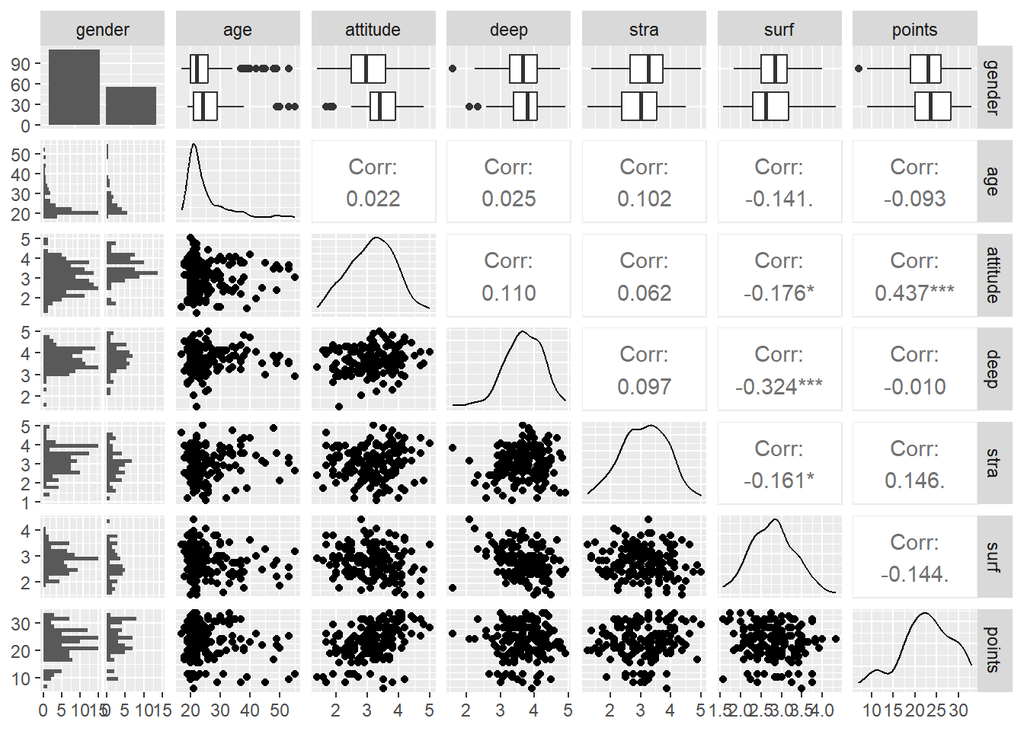

```r
library(ggplot2)

# create a more advanced plot matrix with ggpairs()
p <- ggpairs(learning2014, mapping = aes(), lower = list(combo = wrap("facethist", bins = 20)))
p
```

From the top row of the plot, we can see that females and males have quite similar strategy and surface learning values. Ages differ more; females have a lot more outliers, which can be seen from the boxplot. More of the old participants are female. In attitude, females are more close to each other, whereas there are several males that have a bad starting attitude. Deep learning is in essence the same. Same applies to points.

```r
my_model2 <- lm(points ~ attitude + stra + surf, data = learning2014)
summary(my_model2)
```

```
##
## Call:
## lm(formula = points ~ attitude + stra + surf, data = learning2014)
##
## Residuals:
##      Min       1Q   Median       3Q      Max
## -17.1550  -3.4346   0.5156   3.6401  10.8952
##
## Coefficients:
##             Estimate Std. Error t value Pr(>|t|)
## (Intercept)  11.0171     3.6837   2.991  0.00322 **
## attitude      3.3952     0.5741   5.913 1.93e-08 ***
## stra          0.8531     0.5416   1.575  0.11716
## surf         -0.5861     0.8014  -0.731  0.46563
## ---
## Signif. codes:  0 '***' 0.001 '**' 0.01 '*' 0.05 '.' 0.1 ' ' 1
##
## Residual standard error: 5.296 on 162 degrees of freedom
## Multiple R-squared:  0.2074, Adjusted R-squared:  0.1927
## F-statistic: 14.13 on 3 and 162 DF,  p-value: 3.156e-08
```

First, residuals tells us the error between our model and actual results. The smaller residuals, the less error there is between the model results and actual observed points. Estimates are calculations on how much, ceteris paribus, does change in one of the explanatory variables change the dependent variable. If attitude is increased by one points, it increases the points in the exam by 3.3952 according to model. Standard errors are calculated in order to calculate the t value, which can then be used to see if the coefficient is significant, which means that it is highly unlikely that it differs from zero due to chance. Only attitude has a significant relationship with points.

Residual standard error tells us exactly what the name implies: what is the standard deviation of residuals. Smaller is better. R-squared tells us how much of the variance of points does the model explain. In this case, our model explains about 20 % of variance. F-statistic is used to test whether any of the coefficients differ statistically significantly from 0. Since p-value < 0.001 in the F-statistic, we can reject the null hypothesis where none of the coefficients would have values differing from 0.

```r
my_model3 <- lm(points ~ attitude, data = learning2014)
summary(my_model3)
```

```
##
## Call:
## lm(formula = points ~ attitude, data = learning2014)
##
## Residuals:
##      Min       1Q   Median       3Q      Max
## -16.9763  -3.2119   0.4339   4.1534  10.6645
##
## Coefficients:
##             Estimate Std. Error t value Pr(>|t|)
## (Intercept)  11.6372     1.8303   6.358 1.95e-09 ***
## attitude      3.5255     0.5674   6.214 4.12e-09 ***
## ---
## Signif. codes:  0 '***' 0.001 '**' 0.01 '*' 0.05 '.' 0.1 ' ' 1
##
## Residual standard error: 5.32 on 164 degrees of freedom
## Multiple R-squared:  0.1906, Adjusted R-squared:  0.1856
## F-statistic: 38.61 on 1 and 164 DF,  p-value: 4.119e-09
```

When we fit the model again with only significant coefficients, the median residual decreases. All the coefficients are now statistically significant, and the R-squared did not decrease by much. The F-statistic has a higher value, which means that we can be even more certain that the model fits the data well.

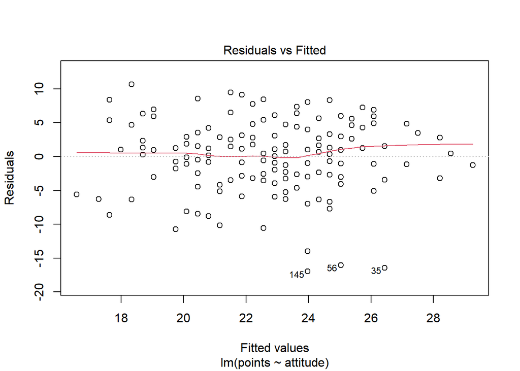

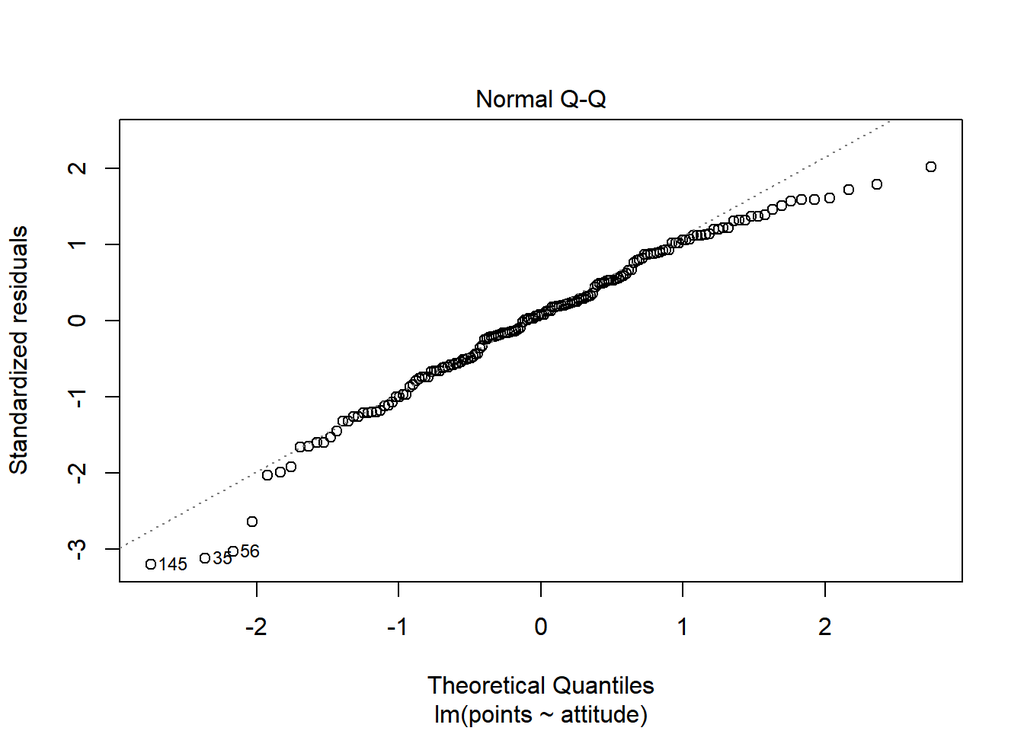

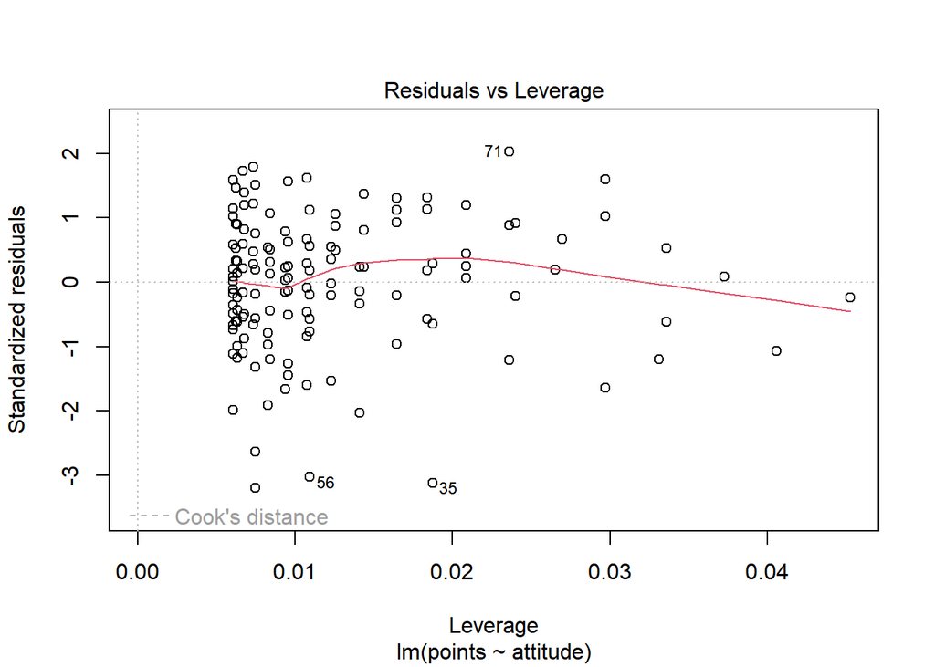

```r
plot(my_model3, which = c(1, 2, 5))
```

To do linear regression in a way that gives us good answers, some assumptions have to be met. These are 1) linear relationship between the explanatory and dependent variables, 2) residuals are independent and do not correlate with each other, 3) variance stays constants no matter the value of explanatory variable and lastly, 4) residuals are normally distributed. All of these can be assessed with the following three plots.

Residuals vs Fitted values shows us if there is outliers in the model and also whether the linearity assumption required for linear regression is fulfilled. It also shows if the residuals correlate with each other and whether the variance stays constant with different fitted values. Residuals are on the y-axis and x-axis has fitted values, which means the models expectation of points with different attitude points. The residuals seem to work as intended, since the large majority is around the horizontal band, which means that the error terms related to variance are quite equal. There are some outliers. The value of these are shown in numbers. It seems that some students with good attitudes managed to score quite low points. We can also see from this plot that residuals are independent and do not correlate with each other.

Normal Q-Q simply shows a line where it is possible to compare if residuals follow a normal distribution. Based on the plot, majority of the residuals in fact do follow normal distribution. The ones who do not are the same values as in the previous plot. All in all, the model is fine based on this.

Lastly, residuals vs leverage plot tells us how the coefficient would change if an observation was removed. In this plot, none of the observations are further than the Cook’s distance. If there would be an observation beyond this distance, removing it would change the coefficient by an amount that is in the x-axis.

All in all, the model we chose fits the data quite well and improves our knowledge in how attitude affects the exam points.